# Lecture 5: Visualization of Network Data

### This layout is just an example and not very helpful - thankfully igraph has a number of built-in layouts, including:

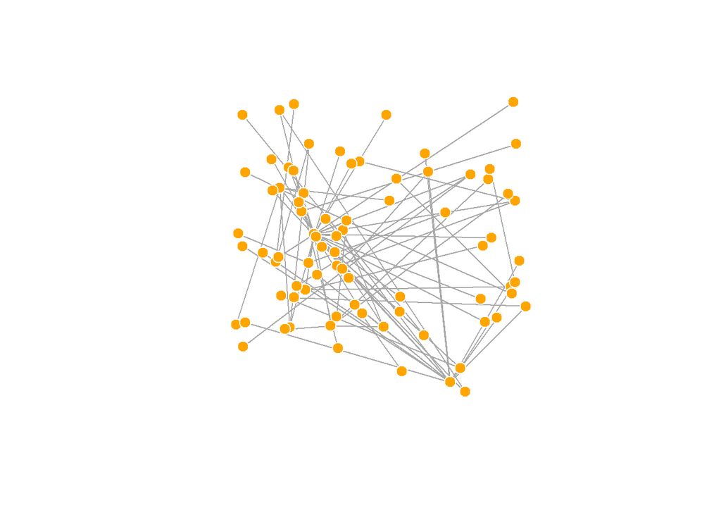

```r
# Randomly placed vertices

l <- layout_randomly(net.bg)

plot(net.bg, layout=l)
```

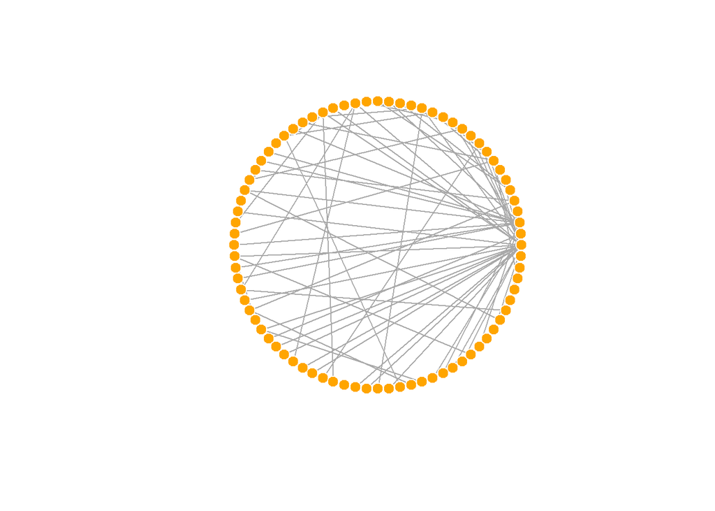

```r
# Circle layout

l <- layout_in_circle(net.bg)

plot(net.bg, layout=l)
```

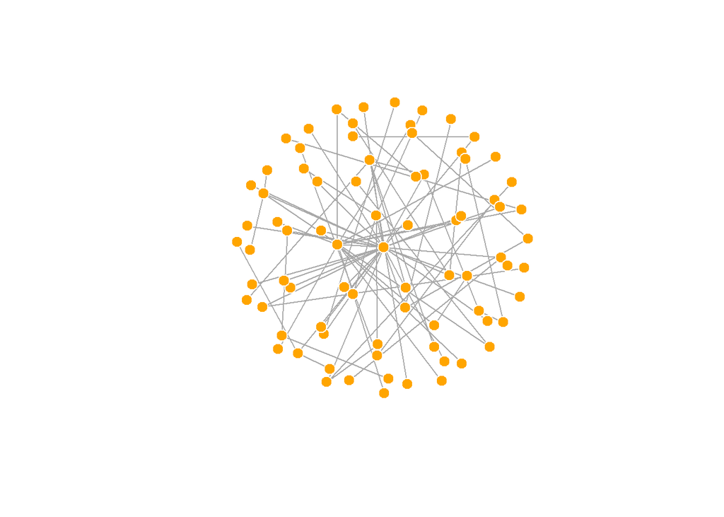

```r
# 3D sphere layout

l <- layout_on_sphere(net.bg)

plot(net.bg, layout=l)
```

### Fruchterman-Reingold is one of the most used force-directed layout algorithms out there.

### Force-directed layouts try to get a nice-looking graph where edges are similar in length and cross each other as little as possible. They simulate the graph as a physical system. Nodes are electrically charged particles that repulse each other when they get too close. The edges act as springs that attract connected nodes closer together. As a result, nodes are evenly distributed through the chart area, and the layout is intuitive in that nodes which share more connections are closer to each other. The disadvantage of these algorithms is that they are rather slow and therefore less often used in graphs larger than ~1000 vertices. You can set the “weight” parameter which increases the attraction forces among nodes connected by heavier edges.

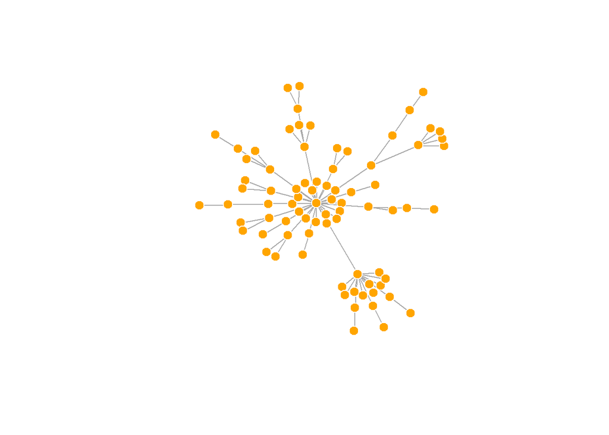

```r
l <- layout_with_fr(net.bg)

plot(net.bg, layout=l)
```

### You will notice that the layout is not deterministic - different runs will result in slightly different configurations. Saving the layout in l allows us to get the exact same result multiple times, which can be helpful if you want to plot the time evolution of a graph, or different relationships – and want nodes to stay in the same place in multiple plots.

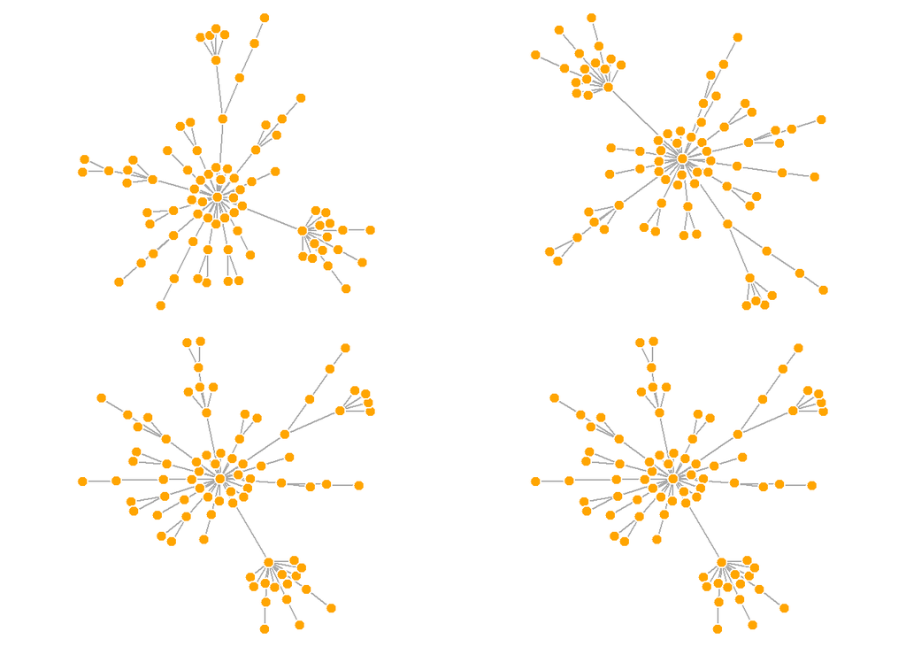

```r
par(mfrow=c(2,2), mar=c(0,0,0,0))   # plot four figures - 2 rows, 2 columns

plot(net.bg, layout=layout_with_fr)

plot(net.bg, layout=layout_with_fr)

plot(net.bg, layout=l)

plot(net.bg, layout=l)
```

```r
dev.off()
```

```r
l <- layout_with_fr(net.bg)
l <- norm_coords(l, ymin=-1, ymax=1, xmin=-1, xmax=1)
```

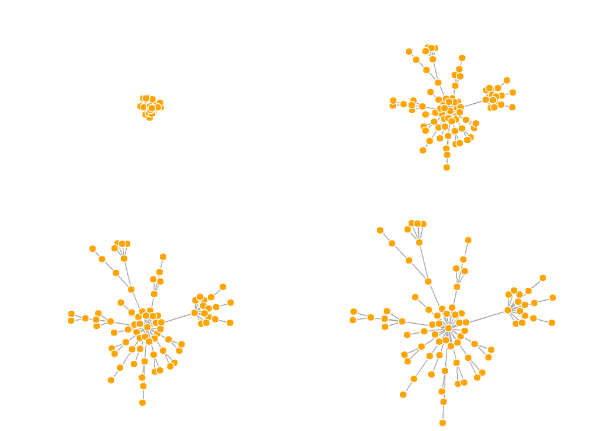

```r
par(mfrow=c(2,2), mar=c(0,0,0,0))

plot(net.bg, rescale=F, layout=l*0.1)

plot(net.bg, rescale=F, layout=l*0.6)

plot(net.bg, rescale=F, layout=l*0.8)

plot(net.bg, rescale=F, layout=l*1.0)
```

### Another popular force-directed algorithm that produces nice results for connected graphs is Kamada Kawai. Like Fruchterman Reingold, it attempts to minimize the energy in a spring system.

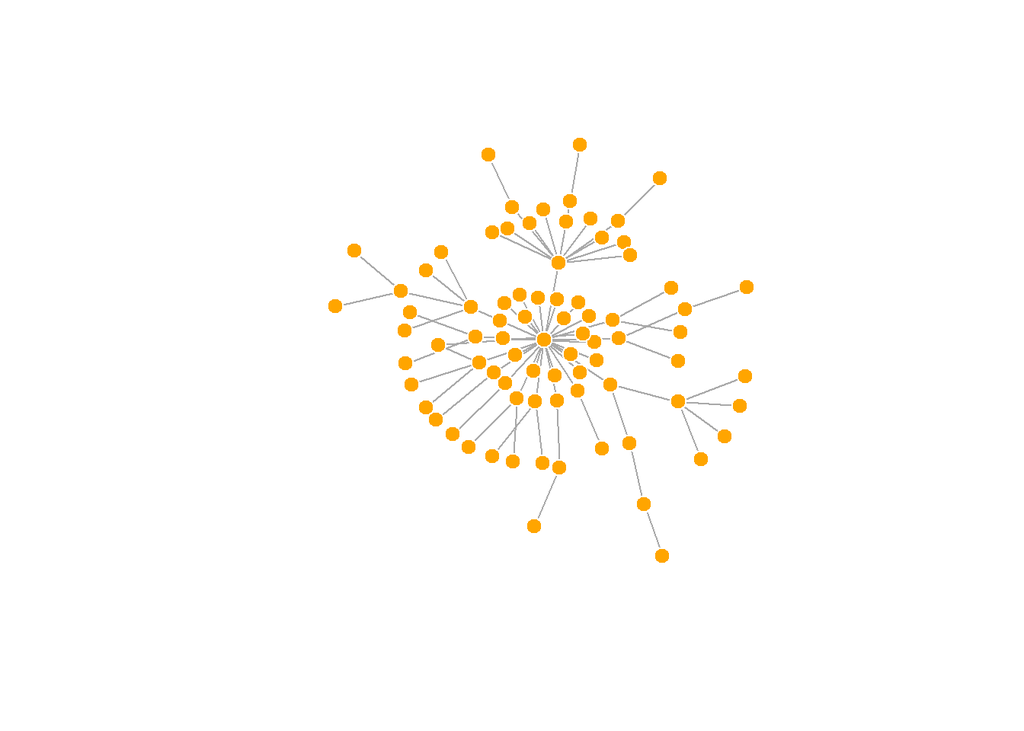

```r
l <- layout_with_kk(net.bg)

plot(net.bg, layout=l)
```

### The LGL algorithm is meant for large, connected graphs. Here you can also specify a root: a node that will be placed in the middle of the layout.

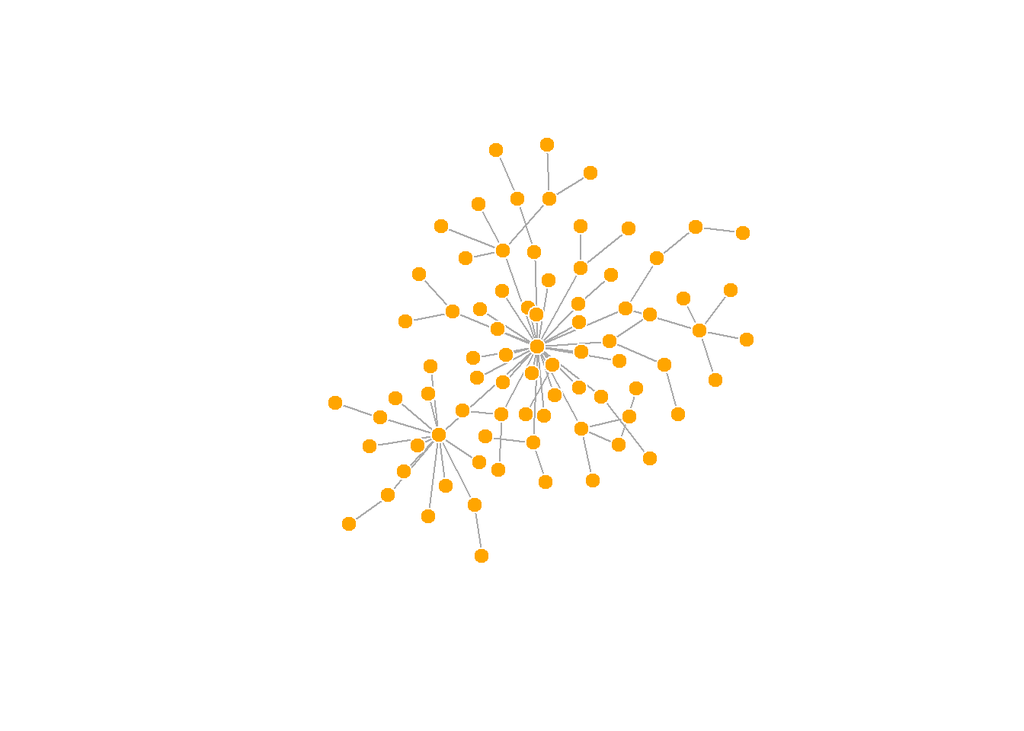

```r
plot(net.bg, layout=layout_with_lgl)
```

## Network layouts (detailed)

### Notice that our network plot is still not too helpful. We can identify the type and size of nodes, but cannot see much about the structure since the links we’re examining are so dense. One way to approach this is to see if we can sparsify the network, keeping only the most important ties and discarding the rest.

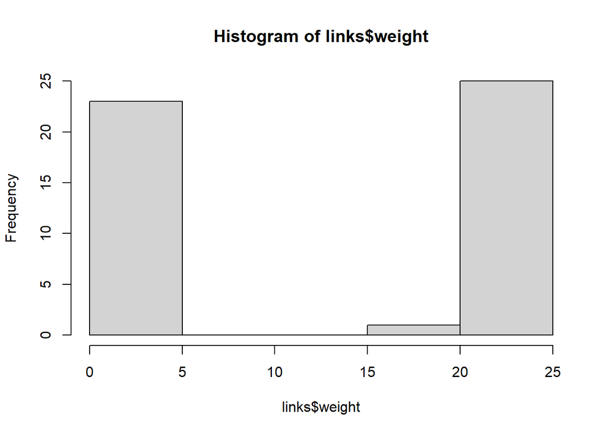

```r
hist(links$weight)
```

```r
mean(links$weight)
```

```
## [1] 12.40816
```

```r
sd(links$weight)
```

```
## [1] 9.905635
```

### There are more sophisticated ways to extract the key edges, but for the purposes of this exercise we’ll only keep ones that have weight higher than the mean for the network. In igraph, we can delete edges using `delete_edges(net, edges)`:

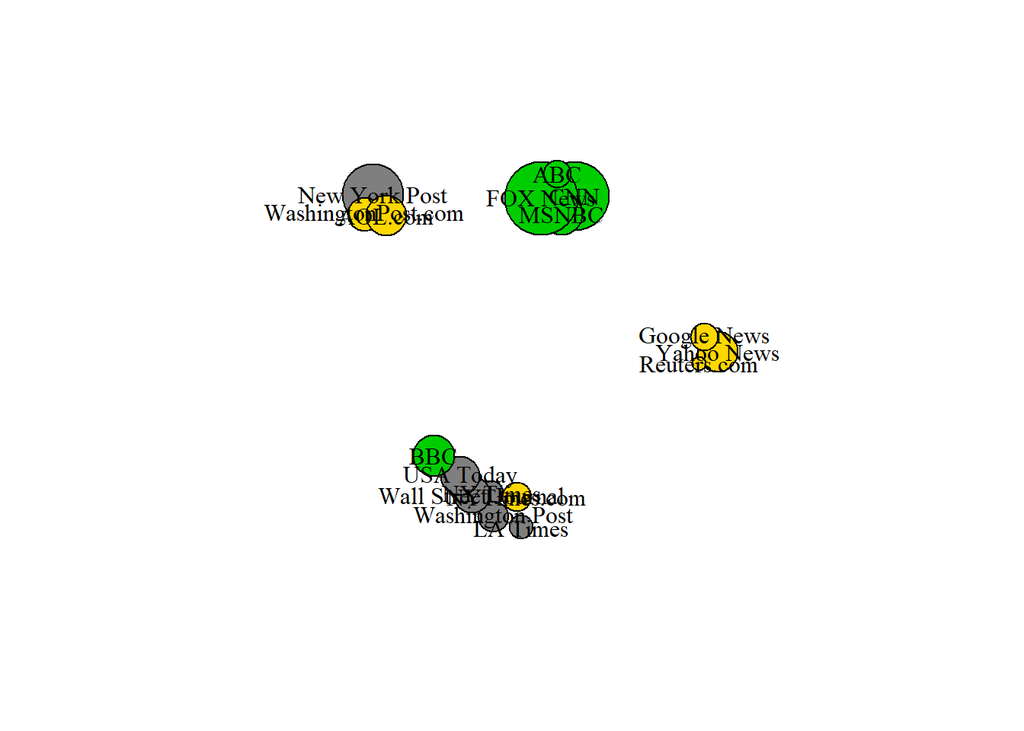

```r
cut.off <- mean(links$weight)

net.sp <- delete_edges(net, E(net)[weight<cut.off])

plot(net.sp)
```

### Another way to think about this is to plot the two tie types (hyperlink & mention) separately.

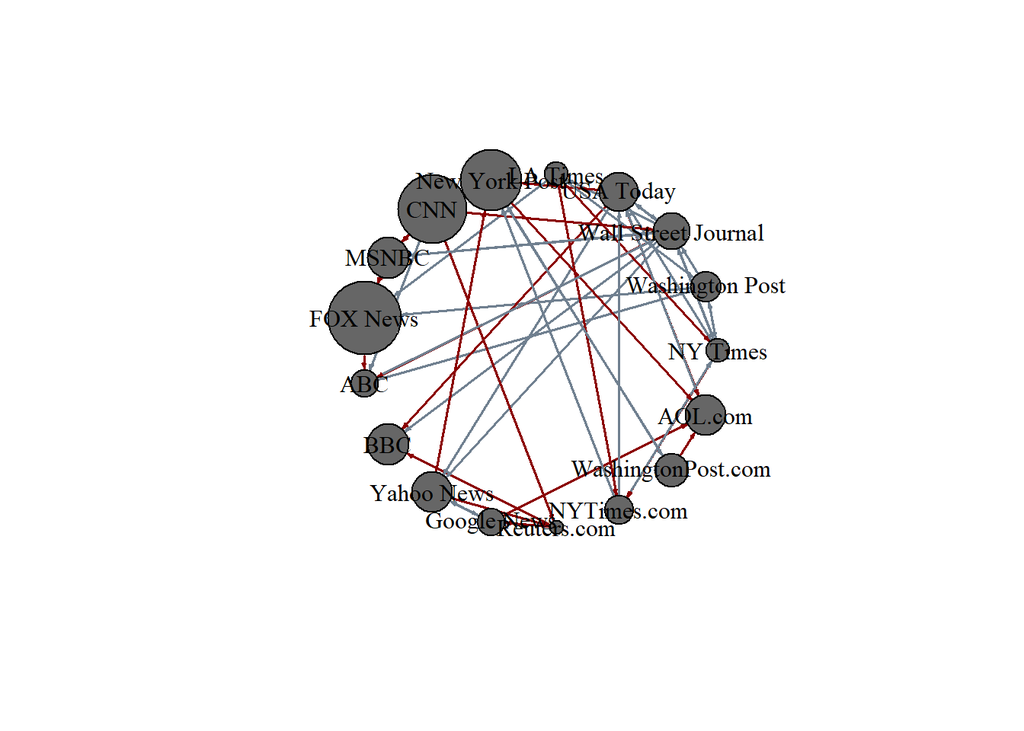

```r
E(net)$width <- 1.5

plot(net, edge.color=c("dark red", "slategrey")[(E(net)$type=="hyperlink")+1],

      vertex.color="gray40", layout=layout.circle)
```

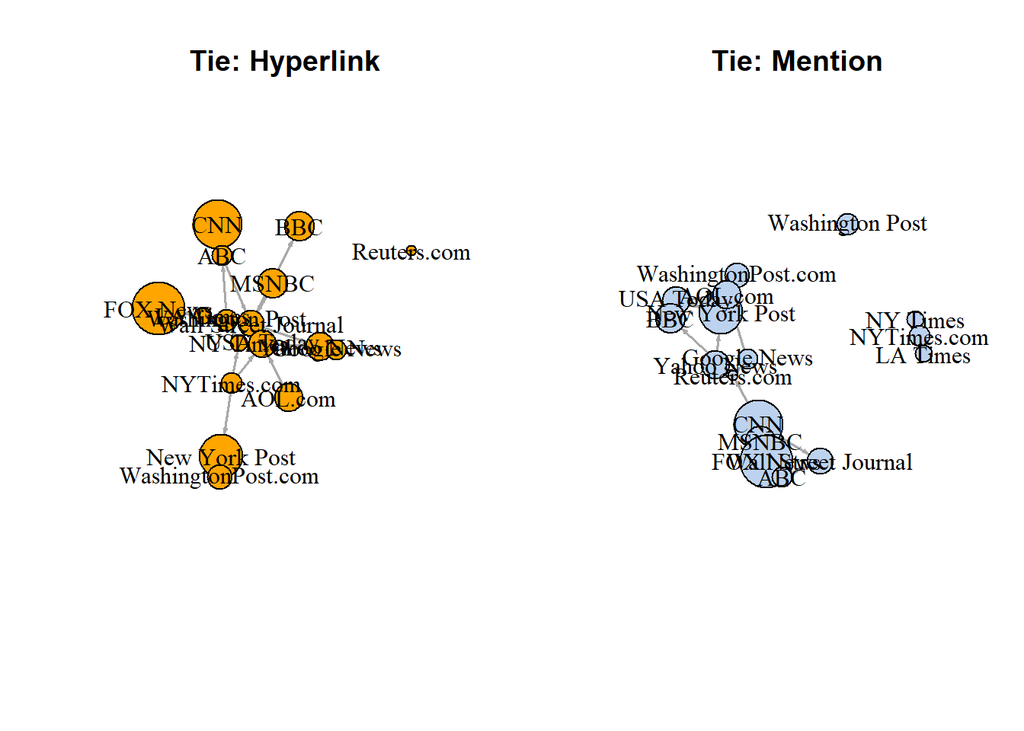

```r
net.m <- net - E(net)[E(net)$type=="hyperlink"] # another way to delete edges

net.h <- net - E(net)[E(net)$type=="mention"]



# Plot the two links separately:

par(mfrow=c(1,2))

plot(net.h, vertex.color="orange", main="Tie: Hyperlink")

plot(net.m, vertex.color="lightsteelblue2", main="Tie: Mention")
```

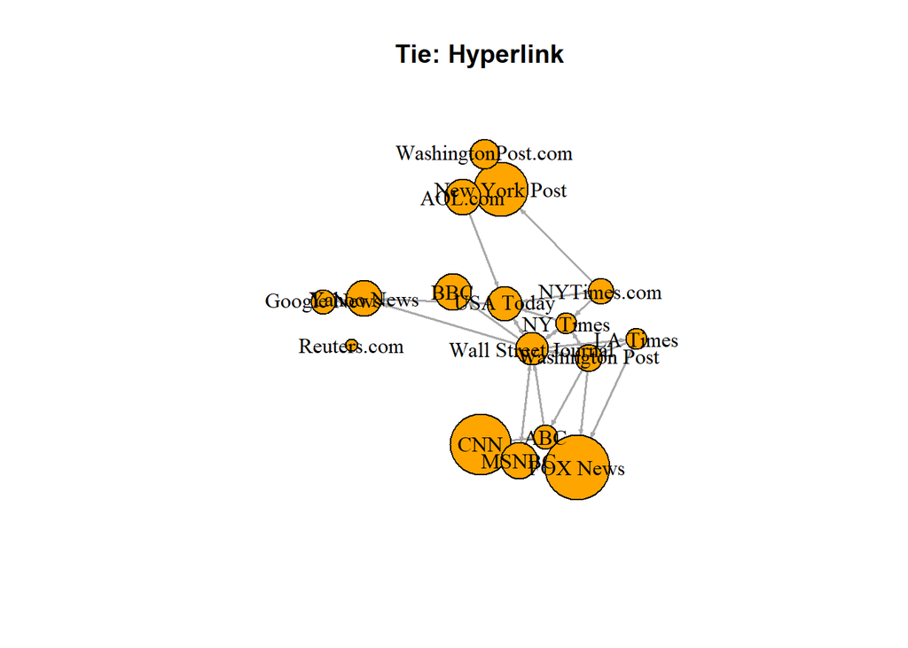

```r
# Make sure the nodes stay in place in both plots:

l <- layout_with_fr(net)

plot(net.h, vertex.color="orange", layout=l, main="Tie: Hyperlink")
```

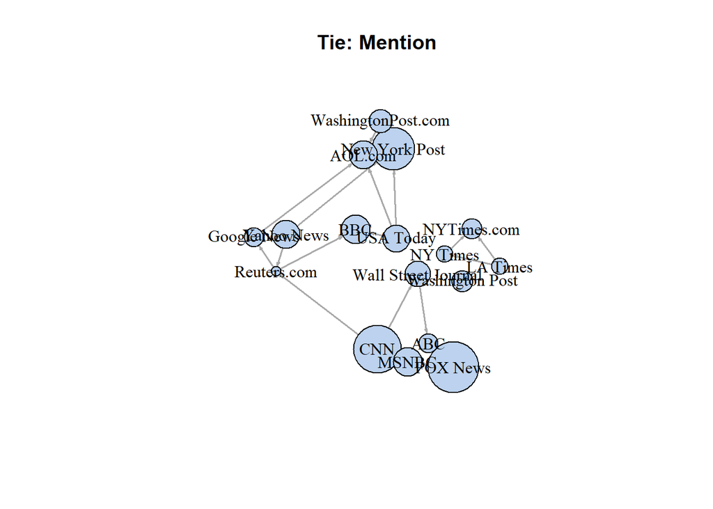

```r
plot(net.m, vertex.color="lightsteelblue2", layout=l, main="Tie: Mention")
```

## Other ways to represent a network

### At this point it might be useful to provide a quick reminder that there are many ways to represent a network not limited to a hairball plot.

### For example, here is a quick heatmap of the network matrix:

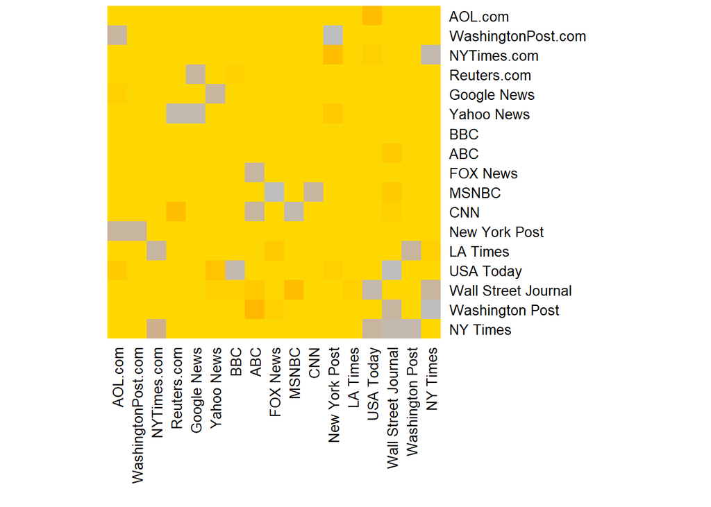

```r
netm <- get.adjacency(net, attr="weight", sparse=F)

colnames(netm) <- V(net)$media

rownames(netm) <- V(net)$media



palf <- colorRampPalette(c("gold", "dark orange","gray"))

heatmap(netm[,17:1], Rowv = NA, Colv = NA, col = palf(100),

        scale="none", margins=c(10,10) )
```

## Plotting two-mode networks with igraph

### As with one-mode networks, we can modify the network object to include the visual properties that will be used by default when plotting the network. Notice that this time we will also change the shape of the nodes - media outlets will be squares, and their users will be circles.

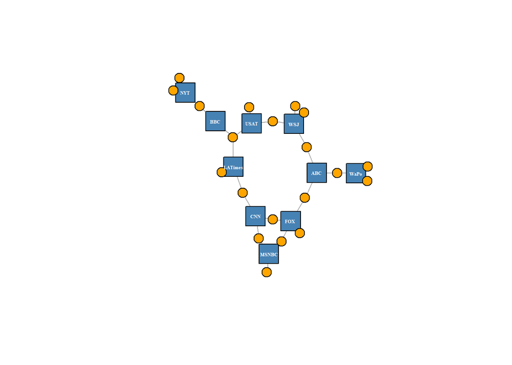

```r
V(net2)$color <- c("steel blue", "orange")[V(net2)$type+1]

V(net2)$shape <- c("square", "circle")[V(net2)$type+1]

V(net2)$label <- ""

V(net2)$label[V(net2)$type==F] <- nodes2$media[V(net2)$type==F]

V(net2)$label.cex=.4

V(net2)$label.font=2



plot(net2, vertex.label.color="white", vertex.size=(2-V(net2)$type)*10)
```

### Igraph also has a special layout for bipartite networks (though it doesn’t always work great, and you might be better off generating your own two-mode layout).

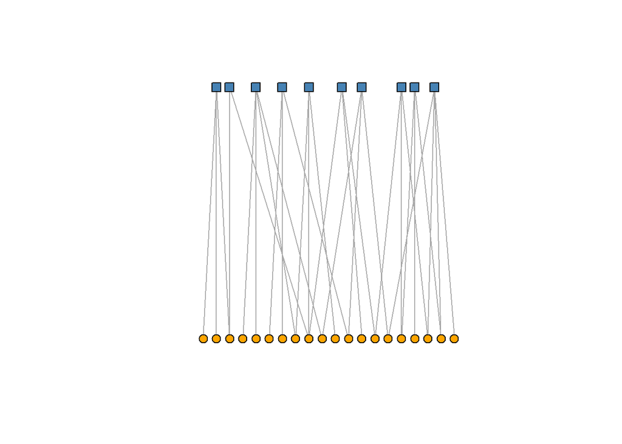

```r
plot(net2, vertex.label=NA, vertex.size=7, layout=layout_as_bipartite)
```

### Using text as nodes may be helpful at times:

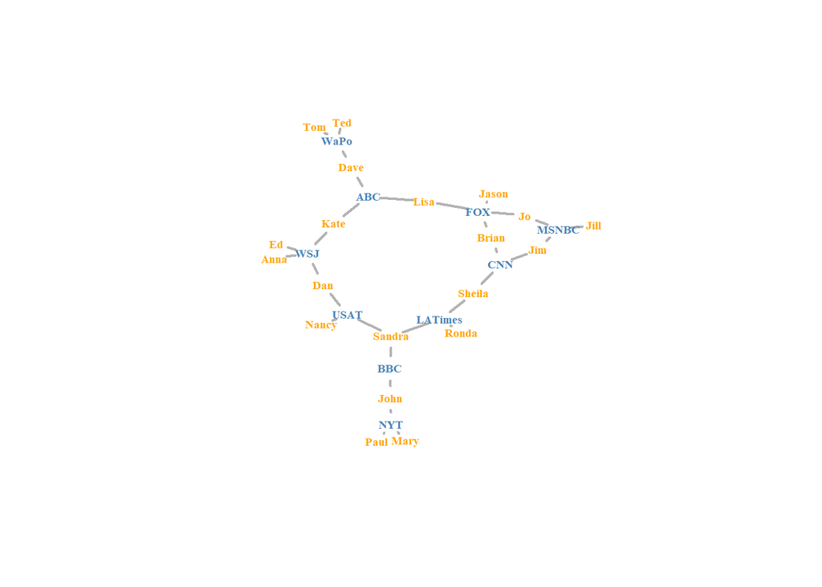

```r
plot(net2, vertex.shape="none", vertex.label=nodes2$media,

     vertex.label.color=V(net2)$color, vertex.label.font=2.5,

     vertex.label.cex=.6, edge.color="gray70",  edge.width=2)
```

# 5.6. Network and node descriptives

## Density

### The proportion of present edges from all possible edges in the network.

```r
edge_density(net, loops=F)
```

```
## [1] 0.1764706
```

```r
ecount(net)/(vcount(net)*(vcount(net)-1)) #for a directed network
```

```
## [1] 0.1764706
```

## Reciprocity

### The proportion of reciprocated ties (for a directed network).

```r
reciprocity(net)
```

```
## [1] 0.4166667
```

```r
dyad_census(net) # Mutual, asymmetric, and nyll node pairs
```

```
## $mut
## [1] 10
##
## $asym
## [1] 28
##
## $null
## [1] 98
```

```r
2*dyad_census(net)$mut/ecount(net) # Calculating reciprocity
```

```
## [1] 0.4166667
```

## Transitivity

### global - ratio of triangles (direction disregarded) to connected triples.

### local - ratio of triangles to connected triples each vertex is part of.

```r
transitivity(net, type="global")  # net is treated as an undirected network
```

```
## [1] 0.372549
```

```r
transitivity(as.undirected(net, mode="collapse")) # same as above
```

```
## [1] 0.372549
```

```r
transitivity(net, type="local")
```

```
##  [1] 0.2142857 0.4000000 0.1153846 0.1944444 0.5000000 0.2666667 0.2000000
##  [8] 0.1000000 0.3333333 0.3000000 0.3333333 0.2000000 0.1666667 0.1666667
## [15] 0.3000000 0.3333333 0.2000000
```

```r
triad_census(net) # for directed networks
```

```
##  [1] 244 241  80  13  11  27  15  22   4   1   8   4   4   3   3   0
```

### Triad types (per Davis & Leinhardt):

### * 003 A, B, C, empty triad.

### * 012 A->B, C

### * 102 A<->B, C

### * 021D A<-B->C

### * 021U A->B<-C

### * 021C A->B->C

### * 111D A<->B<-C

### * 111U A<->B->C

### * 030T A->B<-C, A->C

### * 030C A<-B<-C, A->C.

### * 201 A<->B<->C.

### * 120D A<-B->C, A<->C.

### * 120U A->B<-C, A<->C.

### * 120C A->B->C, A<->C.

### * 210 A->B<->C, A<->C.

### * 300 A<->B<->C, A<->C, completely connected.

## Diameter

### A network diameter is the longest geodesic distance (length of the shortest path between two nodes) in the network. In igraph, `diameter()` returns the distance, while `get_diameter()` returns the nodes along the first found path of that distance.

### Note that edge weights are used by default, unless set to `NA`.

```r
diameter(net, directed=F, weights=NA)
```

```
## [1] 4
```

```r
diameter(net, directed=F)
```

```
## [1] 28
```

```r
diam <- get_diameter(net, directed=T)

diam
```

```
## + 7/17 vertices, named, from 2d8ea53:
## [1] s12 s06 s17 s04 s03 s08 s07
```

### Note that `get_diameter()` returns a vertex sequence. Note though that when asked to behaved as a vector, a vertex sequence will produce the numeric indexes of the nodes in it. The same applies for edge sequences.

```r
class(diam)
```

```
## [1] "igraph.vs"
```

```r
as.vector(diam)
```

```
## [1] 12  6 17  4  3  8  7
```

### Color nodes along the diameter:

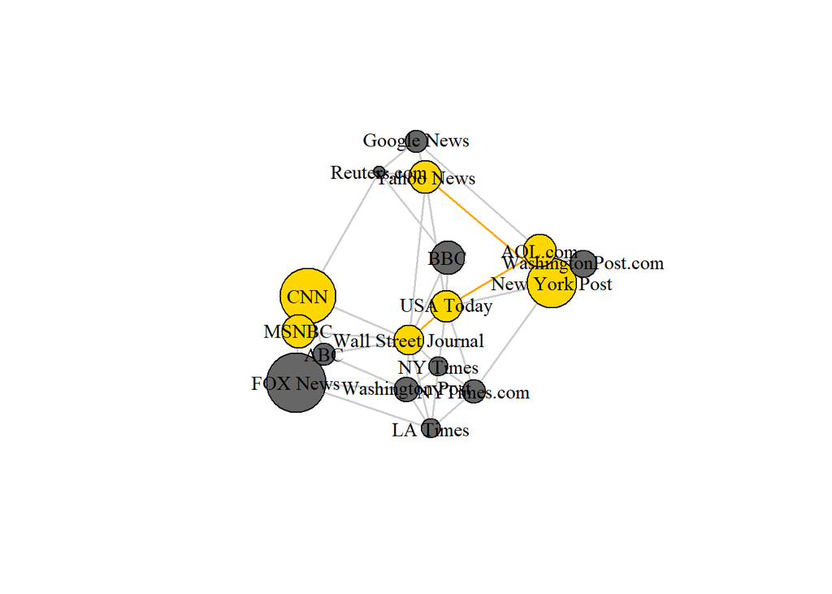

```r
vcol <- rep("gray40", vcount(net))

vcol[diam] <- "gold"

ecol <- rep("gray80", ecount(net))

ecol[E(net, path=diam)] <- "orange"

# E(net, path=diam) finds edges along a path, here 'diam'

plot(net, vertex.color=vcol, edge.color=ecol, edge.arrow.mode=0)
```

## Node degrees

### The function `degree()` has a mode of in for in-degree, out for out-degree, and all or total for total degree.

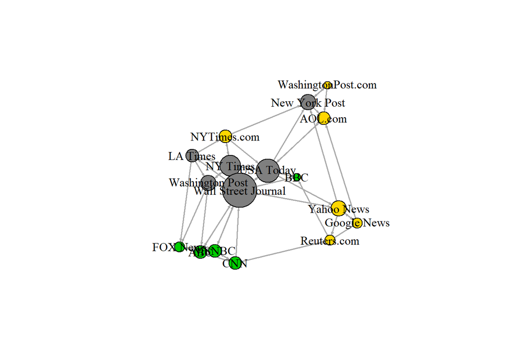

```r
deg <- degree(net, mode="all")

plot(net, vertex.size=deg*3)
```

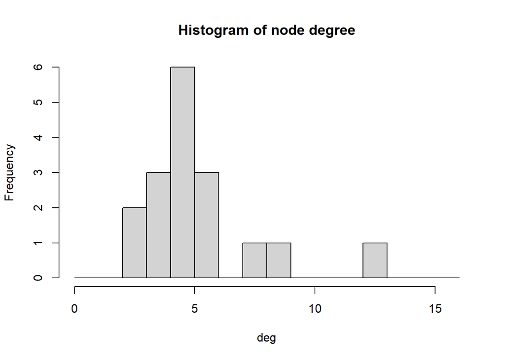

```r
hist(deg, breaks=1:vcount(net)-1, main="Histogram of node degree")
```

## Degree distribution

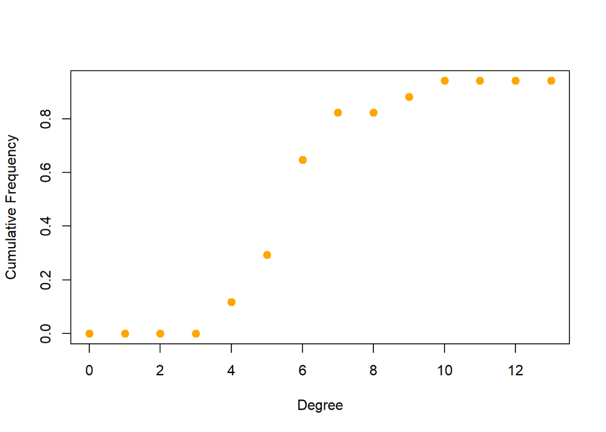

```r
deg.dist <- degree_distribution(net, cumulative=T, mode="all")

plot( x=0:max(deg), y=1-deg.dist, pch=19, cex=1.2, col="orange",

      xlab="Degree", ylab="Cumulative Frequency")
```

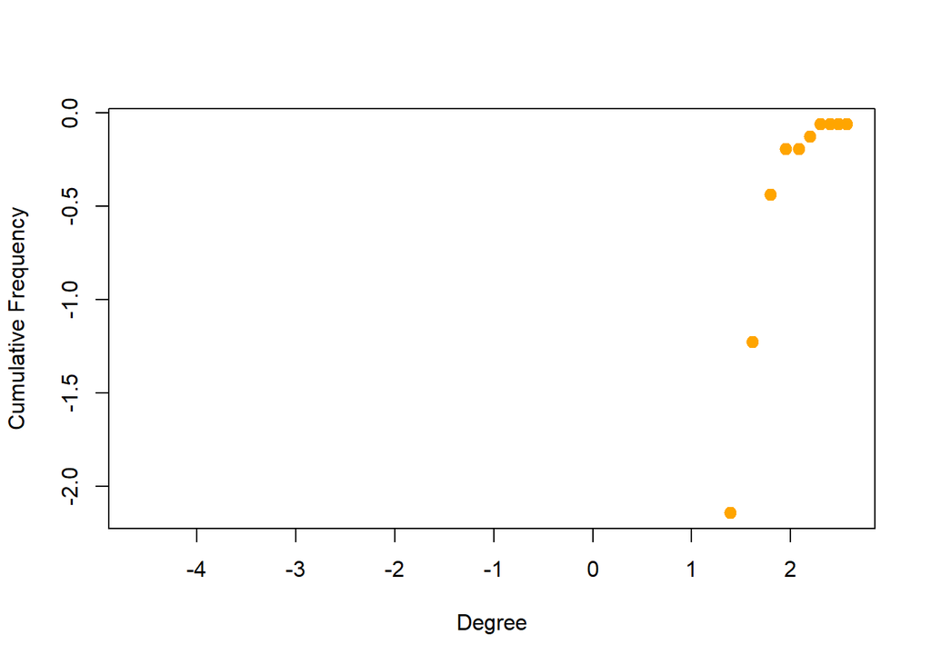

```r
plot( x=log(0:max(deg)+0.01), y=log(1-deg.dist), pch=19, cex=1.2, col="orange",

      xlab="Degree", ylab="Cumulative Frequency")
```

## Centrality & centralization

### Centrality functions (vertex level) and centralization functions (graph level). The centralization functions return `res` - vertex centrality, `centralization`, and `theoretical_max` - maximum centralization score for a graph of that size. The centrality function can run on a subset of nodes (set with the `vids` parameter). This is helpful for large graphs where calculating all centralities may be a resource-intensive and time-consuming task.

### Degree (number of ties)

```r
degree(net, mode="in")
```

```
## s01 s02 s03 s04 s05 s06 s07 s08 s09 s10 s11 s12 s13 s14 s15 s16 s17
##   4   2   6   4   1   4   1   2   3   4   3   3   2   2   2   1   4
```

```r
centr_degree(net, mode="in", normalized=T)
```

```
## $res
##  [1] 4 2 6 4 1 4 1 2 3 4 3 3 2 2 2 1 4
##
## $centralization
## [1] 0.1985294
##
## $theoretical_max
## [1] 272
```

### Closeness (centrality based on distance to others in the graph)

Inverse of the node’s average geodesic distance to others in the network.

```r
closeness(net, mode="all", weights=NA)
```

```
##        s01        s02        s03        s04        s05        s06        s07
## 0.03333333 0.03030303 0.04166667 0.03846154 0.03225806 0.03125000 0.03030303
##        s08        s09        s10        s11        s12        s13        s14
## 0.02857143 0.02564103 0.02941176 0.03225806 0.03571429 0.02702703 0.02941176
##        s15        s16        s17
## 0.03030303 0.02222222 0.02857143
```

```r
centr_clo(net, mode="all", normalized=T)
```

```
## $res
##  [1] 0.5333333 0.4848485 0.6666667 0.6153846 0.5161290 0.5000000 0.4848485
##  [8] 0.4571429 0.4102564 0.4705882 0.5161290 0.5714286 0.4324324 0.4705882
## [15] 0.4848485 0.3555556 0.4571429
##
## $centralization
## [1] 0.3753596
##
## $theoretical_max
## [1] 7.741935
```

### Eigenvector (centrality proportional to the sum of connection centralities)

Values of the first eigenvector of the graph matrix.

```r
eigen_centrality(net, directed=T, weights=NA)
```

[output not shown]

[output cut: 16 more lines]

```
##
## $options$iter
## [1] 7
##
## $options$nconv
## [1] 1
##
## $options$numop
## [1] 31
##
## $options$numopb
## [1] 0
##
## $options$numreo
## [1] 18
```

```r
centr_eigen(net, directed=T, normalized=T)
```

[output not shown]

[output cut: 20 more lines]

```
## $options$numop
## [1] 31
##
## $options$numopb
## [1] 0
##
## $options$numreo
## [1] 18
##
##
## $centralization
## [1] 0.5071775
##
## $theoretical_max
## [1] 16
```

### Betweenness (centrality based on a broker position connecting others)

Number of geodesics that pass through the node or the edge.

```r
betweenness(net, directed=T, weights=NA)
```

```
##         s01         s02         s03         s04         s05         s06
##  24.0000000   5.8333333 127.0000000  93.5000000  16.5000000  20.3333333
##         s07         s08         s09         s10         s11         s12
##   1.8333333  19.5000000   0.8333333  15.0000000   0.0000000  33.5000000
##         s13         s14         s15         s16         s17
##  20.0000000   4.0000000   5.6666667   0.0000000  58.5000000
```

```r
edge_betweenness(net, directed=T, weights=NA)
```

```
##  [1] 10.833333 11.333333  8.333333  9.500000  4.000000 12.500000  3.000000
##  [8]  2.333333 24.000000 16.000000 31.500000 32.500000  9.500000  6.500000
## [15] 23.000000 65.333333 11.000000  6.500000 18.000000  8.666667  5.333333
## [22] 10.000000  6.000000 11.166667 15.000000 21.333333 10.000000  2.000000
## [29]  1.333333  4.500000 11.833333 16.833333  6.833333 16.833333 31.000000
## [36] 17.000000 18.000000 14.500000  7.500000 28.500000  3.000000 17.000000
## [43]  5.666667  9.666667  6.333333  1.000000 15.000000 74.500000
```

```r
centr_betw(net, directed=T, normalized=T)
```

```
## $res
##  [1]  24.0000000   5.8333333 127.0000000  93.5000000  16.5000000  20.3333333
##  [7]   1.8333333  19.5000000   0.8333333  15.0000000   0.0000000  33.5000000
## [13]  20.0000000   4.0000000   5.6666667   0.0000000  58.5000000
##
## $centralization
## [1] 0.4460938
##
## $theoretical_max
## [1] 3840
```

## Hubs and authorities

### The hubs and authorities algorithm developed by Jon Kleinberg was initially used to examine web pages. Hubs were expected to contain catalogs with a large number of outgoing links; while authorities would get many incoming links from hubs, presumably because of their high-quality relevant information.

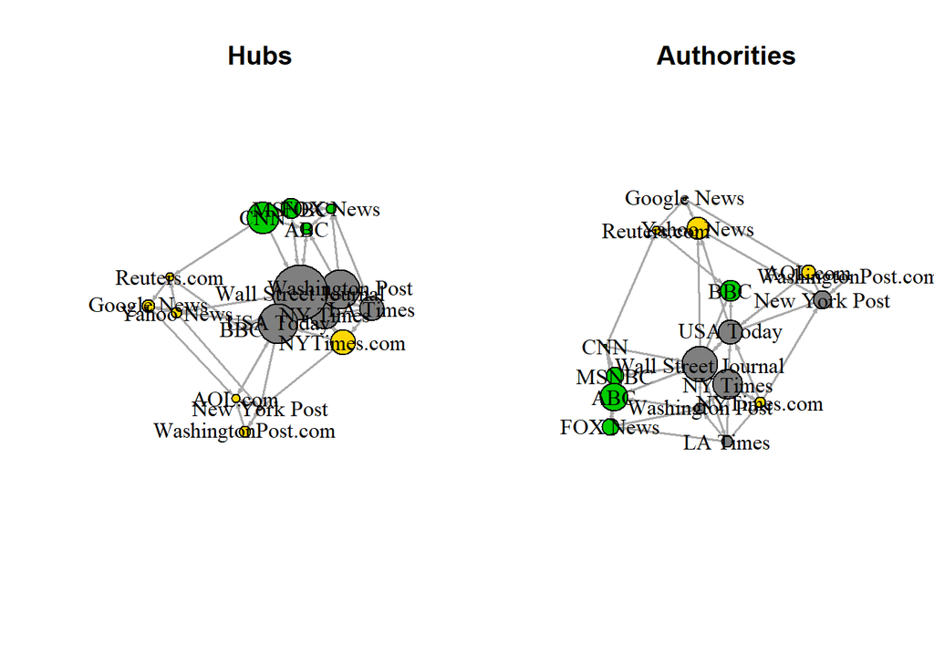

```r
hs <- hub_score(net, weights=NA)$vector

as <- authority_score(net, weights=NA)$vector



par(mfrow=c(1,2))

plot(net, vertex.size=hs*50, main="Hubs")
plot(net, vertex.size=as*30, main="Authorities")
```

# 5.7 Distances and paths

### Average path length: the mean of the shortest distance between each pair of nodes in the network (in both directions for directed graphs).

```r
mean_distance(net, directed=F)
```

```
## [1] 2.058824
```

### We can also find the length of all shortest paths in the graph:

```r
distances(net) # with edge weights
```

```
##     s01 s02 s03 s04 s05 s06 s07 s08 s09 s10 s11 s12 s13 s14 s15 s16 s17
## s01   0   4   2   6   1   5   3   4   3   4   3   3   9   4   7  26   8
## s02   4   0   4   8   3   7   5   6   1   5   5   5  11   6   9  28  10
## s03   2   4   0   4   1   3   1   2   3   2   1   1   7   2   5  24   6
## s04   6   8   4   0   5   1   5   6   7   6   5   3   3   6   1  22   2
## s05   1   3   1   5   0   4   2   3   2   3   2   2   8   3   6  25   7
## s06   5   7   3   1   4   0   4   5   6   5   4   2   4   5   2  21   3
## s07   3   5   1   5   2   4   0   3   4   3   2   2   8   3   6  25   7
## s08   4   6   2   6   3   5   3   0   5   4   3   3   9   4   7  26   8
## s09   3   1   3   7   2   6   4   5   0   5   4   4  10   5   8  27   9
## s10   4   5   2   6   3   5   3   4   5   0   3   3   9   4   7  26   8
## s11   3   5   1   5   2   4   2   3   4   3   0   2   8   1   6  25   7
## s12   3   5   1   3   2   2   2   3   4   3   2   0   6   3   4  23   5
## s13   9  11   7   3   8   4   8   9  10   9   8   6   0   9   4  22   1
## s14   4   6   2   6   3   5   3   4   5   4   1   3   9   0   7  26   8
## s15   7   9   5   1   6   2   6   7   8   7   6   4   4   7   0  23   3
## s16  26  28  24  22  25  21  25  26  27  26  25  23  22  26  23   0  21
## s17   8  10   6   2   7   3   7   8   9   8   7   5   1   8   3  21   0
```

```r
distances(net, weights=NA) # ignore weights
```

```
##     s01 s02 s03 s04 s05 s06 s07 s08 s09 s10 s11 s12 s13 s14 s15 s16 s17
## s01   0   1   1   1   1   2   2   2   2   2   2   2   3   3   1   3   2
## s02   1   0   1   2   1   3   2   2   1   1   2   2   3   3   2   4   3
## s03   1   1   0   1   1   2   1   1   2   1   1   1   2   2   2   3   2
## s04   1   2   1   0   2   1   2   2   3   2   1   1   2   2   1   2   1
## s05   1   1   1   2   0   2   2   2   1   2   2   2   3   3   1   3   3
## s06   2   3   2   1   2   0   3   3   3   3   2   1   2   2   1   1   1
## s07   2   2   1   2   2   3   0   1   2   1   2   2   2   1   3   4   3
## s08   2   2   1   2   2   3   1   0   1   2   2   2   3   2   3   4   3
## s09   2   1   2   3   1   3   2   1   0   1   3   3   4   3   2   4   4
## s10   2   1   1   2   2   3   1   2   1   0   2   2   3   2   3   4   3
## s11   2   2   1   1   2   2   2   2   3   2   0   2   2   1   2   3   2
## s12   2   2   1   1   2   1   2   2   3   2   2   0   1   1   2   2   2
## s13   3   3   2   2   3   2   2   3   4   3   2   1   0   1   3   2   1
## s14   3   3   2   2   3   2   1   2   3   2   1   1   1   0   3   3   2
## s15   1   2   2   1   1   1   3   3   2   3   2   2   3   3   0   2   2
## s16   3   4   3   2   3   1   4   4   4   4   3   2   2   3   2   0   1
## s17   2   3   2   1   3   1   3   3   4   3   2   2   1   2   2   1   0
```

### We can extract the distances to a node or set of nodes we are interested in. Here we will get the distance of every media from the New York Times.

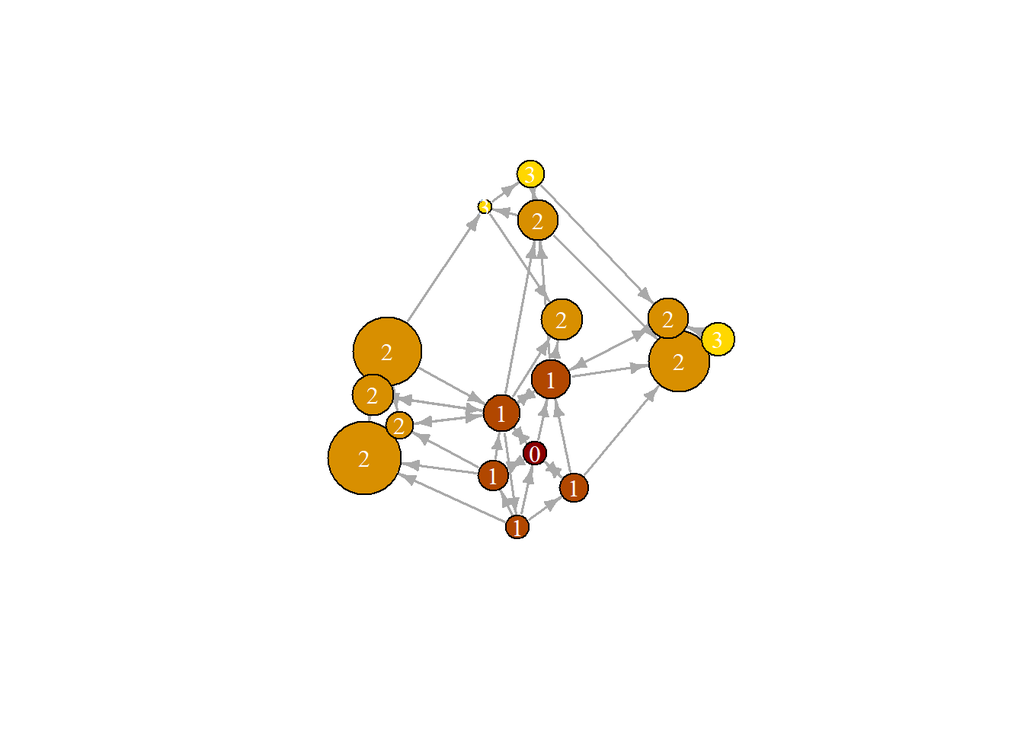

```r
dist.from.NYT <- distances(net, v=V(net)[media=="NY Times"], to=V(net), weights=NA)



# Set colors to plot the distances:

oranges <- colorRampPalette(c("dark red", "gold"))

col <- oranges(max(dist.from.NYT)+1)

col <- col[dist.from.NYT+1]



plot(net, vertex.color=col, vertex.label=dist.from.NYT, edge.arrow.size=.6,

     vertex.label.color="white")
```

### We can also find the shortest path between specific nodes. Say here between MSNBC and the New York Post:

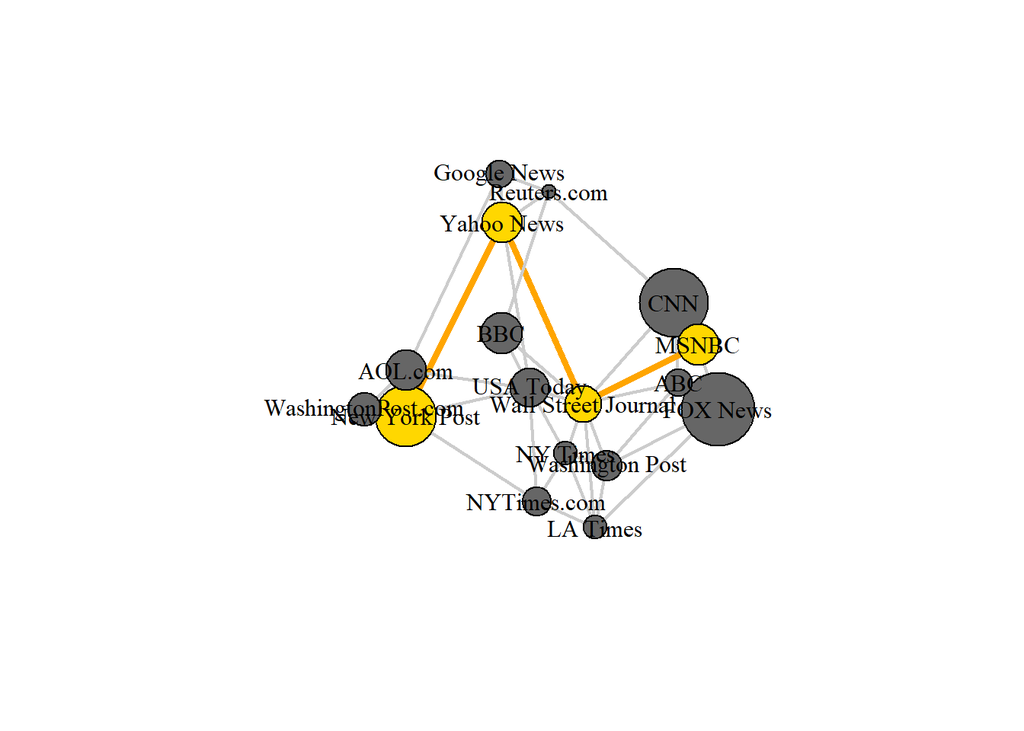

```r
news.path <- shortest_paths(net,

                            from = V(net)[media=="MSNBC"],

                             to  = V(net)[media=="New York Post"],

                             output = "both") # both path nodes and edges



# Generate edge color variable to plot the path:

ecol <- rep("gray80", ecount(net))

ecol[unlist(news.path$epath)] <- "orange"

# Generate edge width variable to plot the path:

ew <- rep(2, ecount(net))

ew[unlist(news.path$epath)] <- 4

# Generate node color variable to plot the path:

vcol <- rep("gray40", vcount(net))

vcol[unlist(news.path$vpath)] <- "gold"



plot(net, vertex.color=vcol, edge.color=ecol,

     edge.width=ew, edge.arrow.mode=0)
```

# 5.8 Groups

##Community detection

### A number of algorithms aim to detect groups that consist of densely connected nodes with fewer connections across groups.

### *Community detection based on edge betweenness (Newman-Girvan)*

### High-betweenness edges are removed sequentially (recalculating at each step) and the best partitioning of the network is selected.

```r
ceb <- cluster_edge_betweenness(net)
```

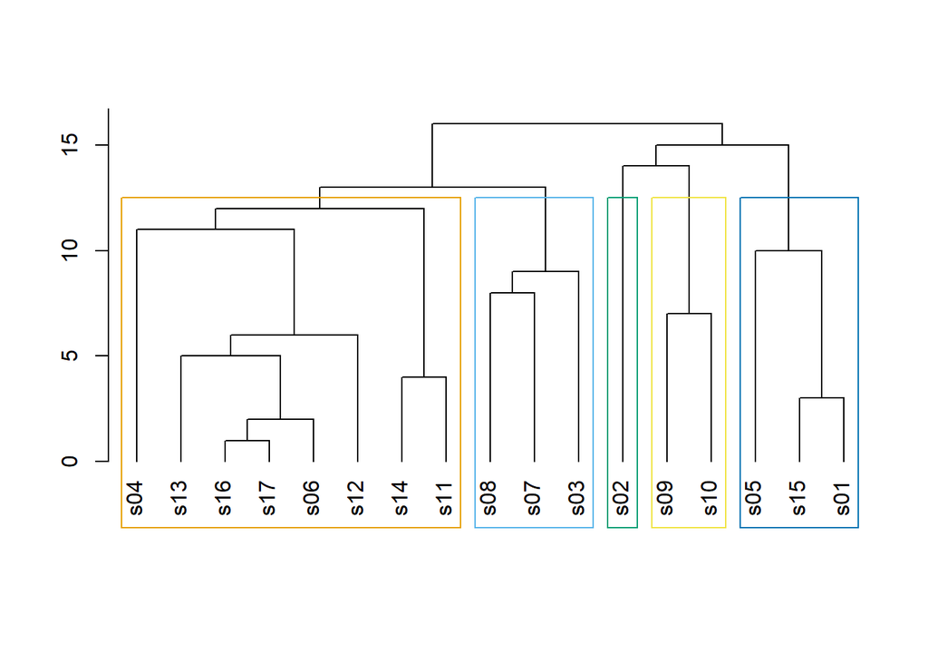

```r
dendPlot(ceb, mode="hclust")
```

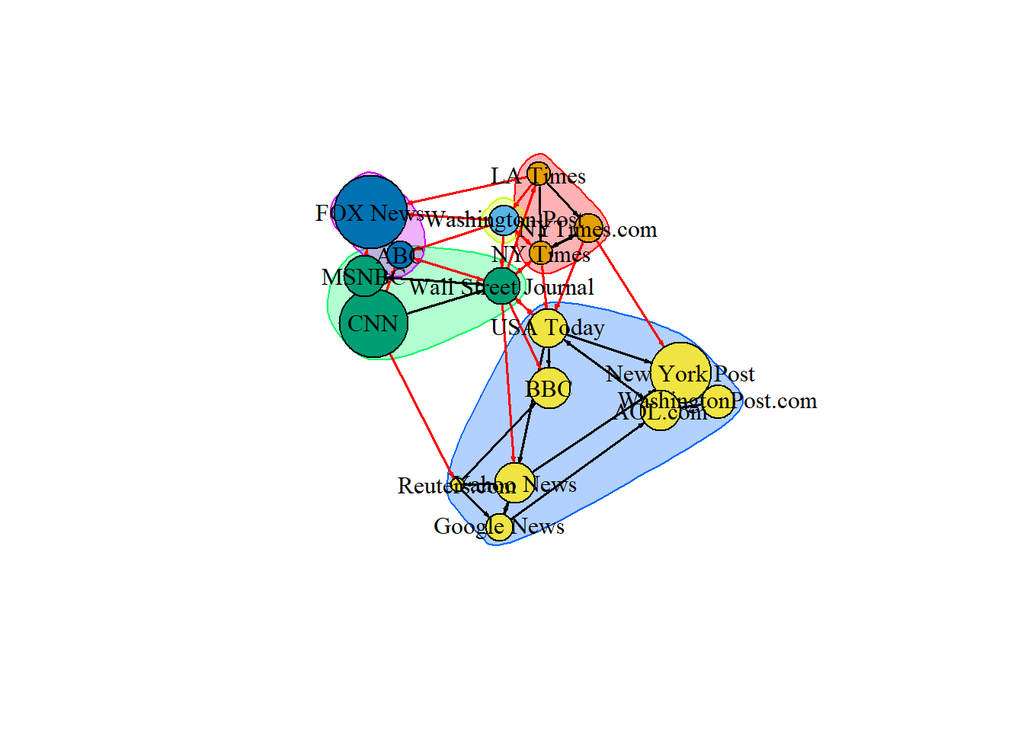

```r
plot(ceb, net)
```

### Let’s examine the community detection igraph object:

```r
class(ceb)
```

```
## [1] "communities"
```

```r
length(ceb)
```

```
## [1] 5
```

```r
membership(ceb) # community membership for each node
```

```
## s01 s02 s03 s04 s05 s06 s07 s08 s09 s10 s11 s12 s13 s14 s15 s16 s17
##   1   2   3   4   1   4   3   3   5   5   4   4   4   4   1   4   4
```

```r
modularity(ceb) # how modular the graph partitioning is
```

```
## [1] 0.292476
```

### *Community detection based on based on propagating labels*

### Assigns node labels, randomizes, than replaces each vertex’s label with the label that appears most frequently among neighbors. Those steps are repeated until each vertex has the most common label of its neighbors.

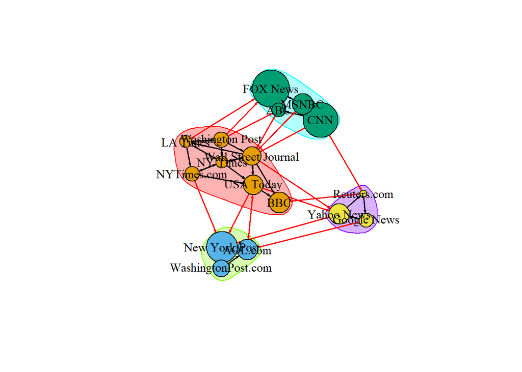

```r
clp <- cluster_label_prop(net)

plot(clp, net)
```

*Community detection based on greedy optimization of modularity*

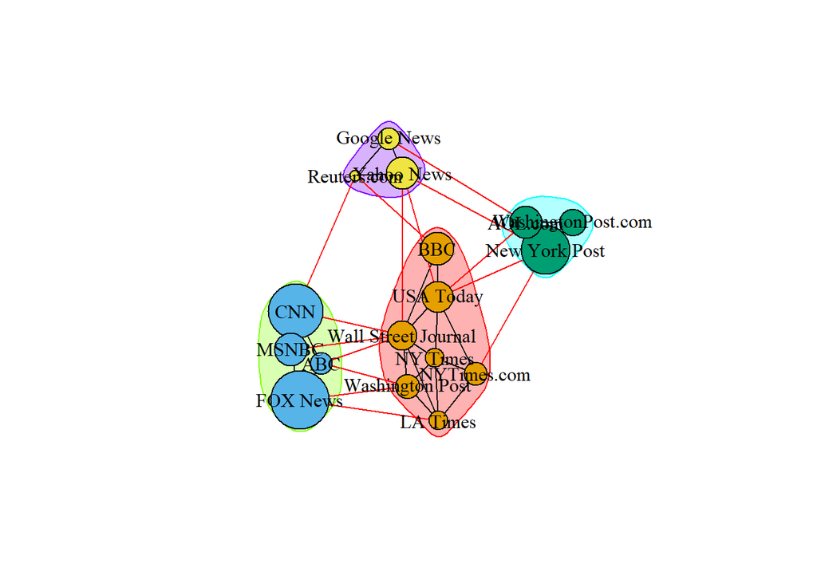

```r
cfg <- cluster_fast_greedy(as.undirected(net))

plot(cfg, as.undirected(net))
```

### We can also plot the communities without relying on their built-in plot:

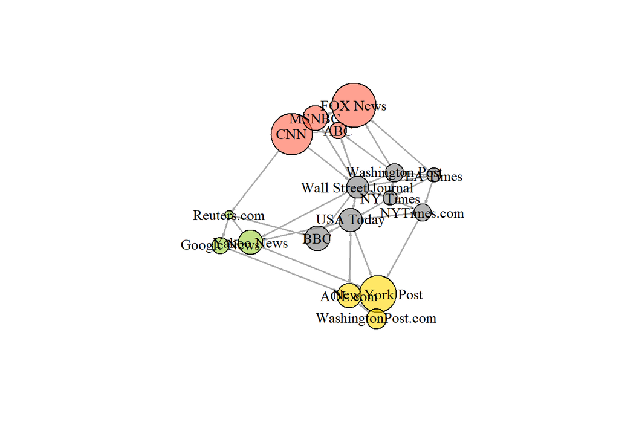

```r
V(net)$community <- cfg$membership

colrs <- adjustcolor( c("gray50", "tomato", "gold", "yellowgreen"), alpha=.6)

plot(net, vertex.color=colrs[V(net)$community])
```